# Taxonomic Analysis with R

**Time**

- Teaching: 40 min
- Exercises: 20 min

**Questions**

- How can we know which taxa are in our samples?
- How can we compare depth-contrasting samples?
- How can we manipulate our data to deliver a message?

**Objectives**

- Manipulate data types inside your phyloseq object.
- Extract specific information from taxonomic-assignation data.

## Explore our samples at specific taxonomic levels

With the taxonomic assignment information that we obtained from Kraken, we have measured diversity, and we have visualized the taxa inside each sample with Krona and Pavian, but Phyloseq allows us to make this visualization more flexible and personalized. So now, we will use Phyloseq to make abundance plots of the taxa in our samples.

We will start our exploration at the Phylum level. In order to group all the OTUs that have the same taxonomy at a certain taxonomic rank, we will use the function `tax_glom()`.

```
> percentages_glom <- tax_glom(percentages, taxrank = 'Phylum')
> View(percentages_glom@tax_table@.Data)
```

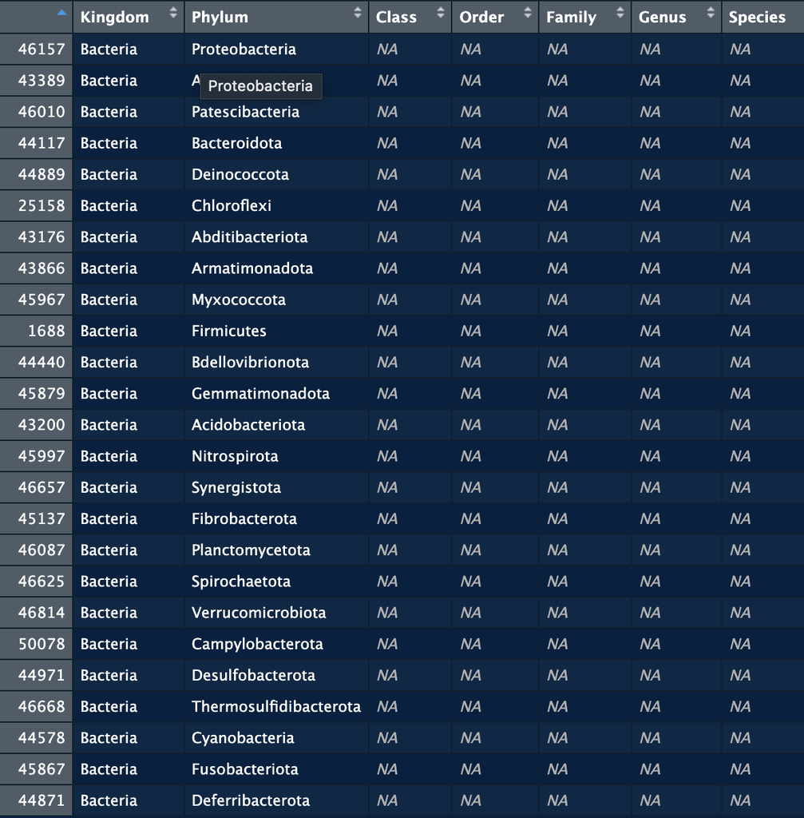

Taxonomic-data table after agglomeration at the phylum level

Another phyloseq function is `psmelt()`, which melts phyloseq objects into a `data.frame` to manipulate them with packages like `ggplot2` and `vegan`.

```
> percentages_df <- psmelt(percentages_glom)
> str(percentages_df)

'data.frame':   75 obs. of  6 variables:
 $ OTU      : chr  "46157" "46157" "46157" "43389" ...
 $ Sample   : chr  "2-kraken_report" "0-kraken_report" "1-kraken_report" "2-kraken_report" ...
 $ Abundance: num  49.4 48 46.2 34.8 30.8 ...
 $ Id       : chr  "2-kraken_report" "0-kraken_report" "1-kraken_report" "2-kraken_report" ...
 $ Kingdom  : chr  "Bacteria" "Bacteria" "Bacteria" "Bacteria" ...
 $ Phylum   : chr  "Proteobacteria" "Proteobacteria" "Proteobacteria" "Actinobacteriota" ...
```

Now, let’s create another data frame with the original data. This structure will help us to compare the absolute with the relative abundance and have a complete picture of our samples.

```
> absolute_glom <- tax_glom(physeq = merged_metagenomes, taxrank = "Phylum")
> absolute_df <- psmelt(absolute_glom)
> str(absolute_df)

'data.frame':   75 obs. of  6 variables:
 $ OTU      : chr  "46157" "46157" "43389" "46157" ...
 $ Sample   : chr  "2-kraken_report" "1-kraken_report" "2-kraken_report" "0-kraken_report" ...
 $ Abundance: num  20055 17043 14131 12077 11343 ...
 $ Id       : chr  "2-kraken_report" "1-kraken_report" "2-kraken_report" "0-kraken_report" ...
 $ Kingdom  : chr  "Bacteria" "Bacteria" "Bacteria" "Bacteria" ...
 $ Phylum   : chr  "Proteobacteria" "Proteobacteria" "Actinobacteriota" "Proteobacteria" ...
```

With these objects and what we have learned regarding R data structures and `ggplot2`, we can compare them with a plot. First, let’s take some steps that will allow us to personalise our plot, making it accessible for color blindness.

We will create a color palette. With `colorRampPalette`, we will choose eight colors from the Dark2 palette and make a “ramp” with it; that is, convert those eight colors to the number of colors needed to have one for each phylum in our data frame. We need to have our Phylum column in the factor structure for this.

```
> absolute_df$Phylum <- as.factor(absolute_df$Phylum)
> phylum_colors_abs<- colorRampPalette(brewer.pal(8,"Dark2")) (length(levels(absolute_df$Phylum)))
```

Now, let´s create the figure for the data with absolute abundances (*, i.e.,* `absolute_plot` object)

```
> absolute_plot <- ggplot(data= absolute_df, aes(x=Sample, y=Abundance, fill=Phylum))+
    geom_bar(aes(), stat="identity", position="stack")+
    scale_fill_manual(values = phylum_colors_abs)
```

With the `position="stack"` command, we are telling the `ggplot` function that the values must stack each other for each sample. In this way, we will have all of our different categories (OTUs) stacked in one bar and not each in a separate one.

For more info [position_stack](https://ggplot2.tidyverse.org/reference/position_stack.html)

Next, we will create the figure for the representation of the relative abundance data and ask RStudio to show us both plots thanks to the `|` function from the library `patchwork`:

```
> percentages_df$Phylum <- as.factor(percentages_df$Phylum)
> phylum_colors_rel<- colorRampPalette(brewer.pal(8,"Dark2")) (length(levels(percentages_df$Phylum)))
> relative_plot <- ggplot(data=percentages_df, aes(x=Sample, y=Abundance, fill=Phylum))+
    geom_bar(aes(), stat="identity", position="stack")+
    scale_fill_manual(values = phylum_colors_rel)
> absolute_plot | relative_plot
```

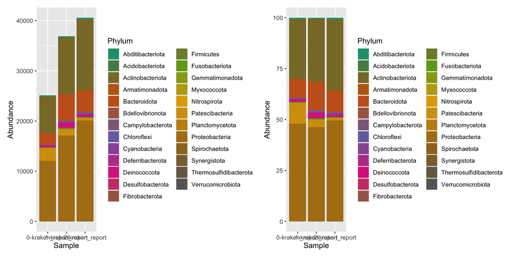

Taxonomic diversity of absolute and relative abundance

```
> percentages_df$Phylum <- as.character(percentages_df$Phylum) # Return the Phylum column to be of type character
> percentages_df$Phylum[percentages_df$Abundance < 0.5] <- "Phyla < 0.5% abund."
> unique(percentages_df$Phylum)

[1] "Proteobacteria"      "Actinobacteriota"    "Bacteroidota"
[4] "Patescibacteria"     "Deinococcota"        "Chloroflexi"
[7] "Abditibacteriota"    "Firmicutes"          "Phyla < 0.5% abund."
```

Let’s ask R to display the figures again by re-running our code:

```
> percentages_df$Phylum <- as.factor(percentages_df$Phylum)
> phylum_colors_rel<- colorRampPalette(brewer.pal(8,"Dark2")) (length(levels(percentages_df$Phylum)))
> relative_plot <- ggplot(data=percentages_df, aes(x=Sample, y=Abundance, fill=Phylum))+
  geom_bar(aes(), stat="identity", position="stack")+
  scale_fill_manual(values = phylum_colors_rel)
> absolute_plot | relative_plot
```

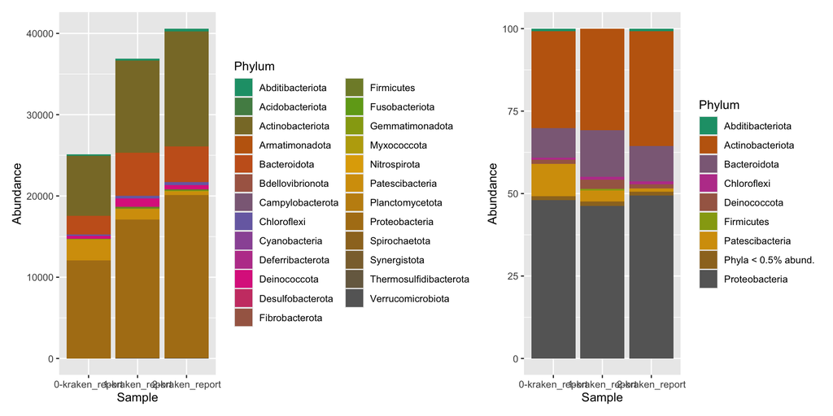

Taxonomic diversity of absolute and relative abundance with corrections

## Going further, let’s take an exciting lineage and explore it thoroughly

As we have already reviewed, Phyloseq offers many tools to manage and explore data. Let’s take a look at a function we already use but now with guided exploration. The `subset_taxa` command is used to extract specific lineages from a stated taxonomic level; we have used it to get rid of the reads that do not belong to bacteria with `merged_metagenomes <- subset_taxa(merged_metagenomes, Kingdom == "Bacteria")`.

We will use it now to extract a specific phylum from our data and explore it at a lower taxonomic level: Genus. We will take as an example the phylum Actionbacteriota, as members of this phylum were found to be enriched in diseased plants:

```
> streptomyces <- subset_taxa(merged_metagenomes, Phylum == "Actinobacteriota")
> unique(streptomyces@tax_table@.Data[,2])
[1] "Actinobacteriota"
```

Let’s do a little review of all that we saw today: **Transformation of the data; Manipulation of the information; and plotting**:

```
> streptomyces_percentages <- transform_sample_counts(streptomyces, function(x) x*100 / sum(x) )
> streptomyces_glom <- tax_glom(streptomyces_percentages, taxrank = "Genus")
> streptomyces_df <- psmelt(streptomyces_glom)
> streptomyces_df$Genus[streptomyces_df$Abundance < 10] <- "Genera < 10.0 abund"
> streptomyces_df$Genus <- as.factor(streptomyces_df$Genus)
> genus_colors_streptomyces <- colorRampPalette(brewer.pal(8,"Dark2")) (length(levels(streptomyces_df$Genus)))
> plot_streptomyces <- ggplot(data=streptomyces_df, aes(x=Sample, y=Abundance, fill=Genus))+
    geom_bar(aes(), stat="identity", position="stack")+
    scale_fill_manual(values = genus_colors_streptomyces)
> plot_streptomyces
```

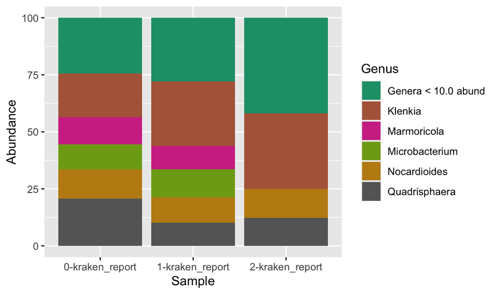

Diversity of Actinobacteriota at genus level inside our samples

**Exercise 1: Taxa agglomeration**

With the following code, in the dataset with absolute abundances, group together the phyla with a small number of reads to have a better visualization of the data. Remember to check the data classes inside your data frame.

According to the [ColorBrewer](https://github.com/axismaps/colorbrewer/) package it is recommended not to have more than nine different colors in a plot.

What is the correct order to run the following chunks of code? Compare your graphs with your partners’.

1. `absolute_df$Phylum <- as.factor(absolute_df$Phylum)`
2. `absolute_plot <- ggplot(data= absolute_df, aes(x=Sample, y=Abundance, fill=Phylum))+`  
   `geom_bar(aes(), stat="identity", position="stack")+`  
   `scale_fill_manual(values = phylum_colors_abs)`
3. `absolute_$Phylum[absolute_$Abundance < 300] <- "Minoritary Phyla"`
4. `phylum_colors_abs<- colorRampPalette(brewer.pal(8,"Dark2")) (length(levels(absolute_df$Phylum)))`
5. `absolute_df$Phylum <- as.character(absolute_df$Phylum)`

**Solution**

By grouping the samples with less than 300 reads, we can get a more decent plot. Certainly, this will be difficult since each sample has a contrasting number of reads.

5. `absolute_df$Phylum <- as.character(absolute_df$Phylum)`
6. `absolute_df$Phylum[absolute_df$Abundance < 300] <- "Minoritary Phyla"`
7. `absolute_df$Phylum <- as.factor(absolute_df$Phylum)`
8. `phylum_colors_abs<- colorRampPalette(brewer.pal(8,"Dark2")) (length(levels(absolute_df$Phylum)))`
9. `absolute_plot <- ggplot(data= absolute_df, aes(x=Sample, y=Abundance, fill=Phylum))+`  
   `geom_bar(aes(), stat="identity", position="stack")+` `scale_fill_manual(values = phylum_colors_abs)`

Show your plots:

`absolute_plot | relative_plot`

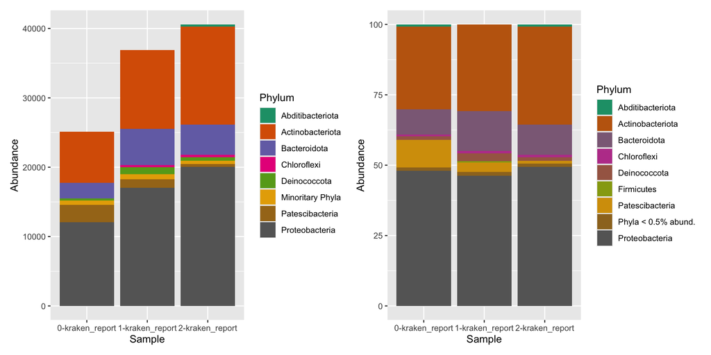

**Exercise 2: Recap of abundance plotting**

Match the chunk of code with its description and put them in the correct order to create a relative abundance plot at the genus level of a particular phylum:

| Description | Command |
| --- | --- |
| plot the relative abundance at the genus levels. | `plot_proteo` |
| Convert all the genera with less than 3% abundance into only one label. | `proteo_percentages <- transform_sample_counts(proteo, function(x) >x*100 / sum(x) )` |
| Make just one row that groups all the observations of the same genus. | `proteo <- subset_taxa(merged_metagenomes, Phylum == "Proteobacteria")` |
| Create a phyloseq object only with the reads assigned to a certain phylum. | `unique(proteo@tax_table@.Data[,2])` |
| Show the plot. | `proteo_glom <- tax_glom(proteo_percentages, taxrank = "Genus")` |
| Transform the phyloseq object to a data frame. | `plot_proteo <- ggplot(data=proteo_df, aes(x=Sample, y=Abundance, fill=Genus))+` |
|  | `geom_bar(aes(), stat="identity", position="stack")+` |
|  | `scale_fill_manual(values = genus_colors_proteo)` |
| Convert the Genus column into the factor structure. | `proteo_df$Genus[proteo_df$Abundance < 3] <- "Genera < 3% abund"` |
| Look at the phyla present in your phyloseq object. | `proteo_df <- psmelt(proteo_glom)` |
| Convert the abundance counts to relative abundance. | `genus_colors_proteo<- colorRampPalette(brewer.pal(8,"Dark2")) (length(levels(proteo_df$Genus)))` |
| Make a palette with the appropriate colors for the number of genera. | `proteo_df$Genus <- as.factor(proteo_df$Genus)` |

**Solution**

```
# Create a phyloseq object only with the reads assigned to a certain phylum.
> proteo <- subset_taxa(merged_metagenomes, Phylum == "Proteobacteria")

# Look at the phyla present in your phyloseq object
> unique(proteo@tax_table@.Data[,2])

# Convert the abundance counts to the relative abundance
> proteo_percentages <- transform_sample_counts(proteo, function(x) x*100 / sum(x) )

# Make just one row that groups all the observations of the same genus.
> proteo_glom <- tax_glom(proteo_percentages, taxrank = "Genus")

# Transform the phyloseq object to a data frame
> proteo_df <- psmelt(proteo_glom)

# Convert all the genera that have less than 3% of abundance into only one label
> proteo_df$Genus[proteo_df$Abundance < 3] <- "Genera < 3% abund"

# Convert the Genus column into the factor structure
> proteo_df$Genus <- as.factor(proteo_df$Genus)

# Make a palette with the appropriate colors for the number of genera
> genus_colors_proteo<- colorRampPalette(brewer.pal(8,"Dark2")) (length(levels(proteo_df$Genus)))

# Plot the relative abundance at the genus levels
> plot_proteo <- ggplot(data=proteo_df, aes(x=Sample, y=Abundance, fill=Genus))+
   geom_bar(aes(), stat="identity", position="stack")+
   scale_fill_manual(values = genus_colors_proteo)

# Show the plot
> plot_proteo
```

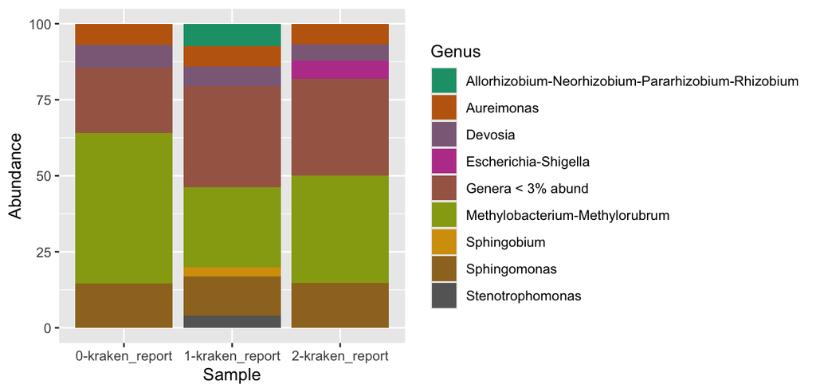

**Keypoints**

- Depths and abundances can be visualized using phyloseq.
- The library `phyloseq` lets you manipulate metagenomic data in a taxonomic specific perspective.